# EDPS 845 Assignment 1

Tony Albano

## Overview

Demonstrate your mastery of concepts and procedures covered in *An Introduction to R*, chapters 1 through 9. See Appendix A for examples.

Complete this assignment by responding to each question below using your own original code, in addition to answering any questions. Follow Google’s [R coding conventions](https://google.github.io/styleguide/Rguide.xml), and use [R markdown](http://rmarkdown.rstudio.com/index.html) formatting for your responses, with example R code written as

```r
# Comment within some example code
```

Your file should have an Rmd extension, and you should check that it compiles to HTML using the *Knit* command in RStudio (this runs `knitr::knit()` on the file). Note that you can already *Knit* this file to see how it works.

## Exercises

### Chapter 1

1. Show that you can access the home page for the HTML R help menu, as well as help files for individual functions.

```r
#This will open html help
help.start()

#Both of the following will open the help file for the solve function
help.solve
?solve
```

2. Demonstrate correct and incorrect naming of R objects.

```r
#Best practice dictates NOT using periods, use _ instead
#names can include a number, but cannot begin with a number
#Every character matters and is case-sensitive

#correct
x1 <- c(1,2,3) #where x1 is the object
X1 <- c(2,3,4) #different from lowercase x1

#incorrect
# 2x <- c(3,4,5)
```

3. How do you list all available objects in the R workspace? And how do you remove individual objects?

```r
# to display the objects which are currently stored within R
objects()
```

```
## [1] "x1" "X1"
```

```r
# to remove individual objects
rm(x1,X1)
```

### Chapter 2

1. Create and index a vector using a logical, integer, negative integer, and character vector.

```r
v1 <- 1:30 #creating a vextor that includes the integers 1, 2,...29, 30

#logical vector index

v1logical <- v1[v1%%2==0] #vector "v1logical" where only the values that are included are those for which the index vector in brackets is TRUE. Here, this would give you only the even values.

# positive integer index

v1first10 <- v1[1:10] #vector that selects the first ten values of vector v1

#negative integer index

v1last10 <- v1[-(1:20)] #vector that excludes values 1-20 of vector v1

#character vector index

faces <- c(12, 11, 36, 24) #creates a vector of those values
names(faces) <- c("happy", "angry", "neutral", "surprised") #assigns names to identify each component of a vector
stim_list1 <- faces[c("neutral", "surprised")] #now I can create another vector comprised of the numeric mode values, without having to remember the specific numeric values because they have names
```

2. Create a simple data frame containing a numeric variable, character variable, and factor with at least 3 levels. Use the data frame to demonstrate how R codes and handles missing data.

### Chapter 3

1. Demonstrate how to check and change the modes and attributes of R objects.

```r
mode(v1) #returns what the mode is; in this case, "numeric"
```

```
## [1] "numeric"
```

```r
length (v1) #returns the length; in this case, 30
```

```
## [1] 30
```

```r
attributes(faces) #returns additional, non-instrinsic attributes, like names
```

```
## $names
## [1] "happy"     "angry"     "neutral"   "surprised"
```

```r
as.character(v1) #changes all numeric values in vector v1 to character mode
```

```
##  [1] "1"  "2"  "3"  "4"  "5"  "6"  "7"  "8"  "9"  "10" "11" "12" "13" "14"
## [15] "15" "16" "17" "18" "19" "20" "21" "22" "23" "24" "25" "26" "27" "28"
## [29] "29" "30"
```

```r
as.integer(v1) #changes all characters in vector v1 back to integer mode
```

```
##  [1]  1  2  3  4  5  6  7  8  9 10 11 12 13 14 15 16 17 18 19 20 21 22 23
## [24] 24 25 26 27 28 29 30
```

```r
v2 <- numeric() #creates empty vector of mode numeric
length (v2) <-20 #makes the length 20, all missing values (NA)
v2[5] <- 5.1 #makes the 5th value 5.1

attr(v2, "dim") <- c(5,4) #changes the dimensions to a 5-by-4 matrix
```

### Chapter 4

1. Complete the exercise on page 17, where you calculate 95% confidence intervals for state mean incomes.

```r
state <- c("tas", "sa", "qld", "nsw", "nsw", "nt", "wa", "wa","qld", "vic", "nsw", "vic", "qld", "qld", "sa", "tas","sa", "nt", "wa", "vic", "qld", "nsw", "nsw", "wa","sa", "act", "nsw", "vic", "vic", "act")

statef <- factor(state)

incomes <- c(60, 49, 40, 61, 64, 60, 59, 54, 62, 69, 70, 42, 56,61, 61, 61, 58, 51, 48, 65, 49, 49, 41, 48, 52, 46,59, 46, 58, 43)

incmeans <- tapply(incomes, statef, mean) #apply the mean() function to each group of income by levels of statef

stderr <- function(x) sqrt(var(x)/length(x)) #creates a funciton to calculate standard error

incster <- tapply (incomes, statef, stderr) #apply the newly created stderr function to each group of income by levels of statef

ns <- table(statef) #get n for each state/providence

qt (.025, ns-1) #returns CI with lower tail included for each n
```

```
## statef
##        act        nsw         nt        qld         sa        tas
## -12.706205  -2.570582 -12.706205  -2.776445  -3.182446 -12.706205
##        vic         wa
##  -2.776445  -3.182446
```

2. In what order are the levels of ordered factors stored in?

```r
#They are stored in alphabetical order, or in the order they were specified to factor if they were specified explicitly

ex1 <- c("blue", "red", "green")
ex1f <- factor (ex1) #alphabetical


ex1f2 <- factor(ex1, levels=c("blue", "red", "green"))
levels(ex1f2) #specified order
```

```
## [1] "blue"  "red"   "green"
```

### Chapter 5

1. Create an array with dimensions `c(3, 6, 2)` and use it to demonstrate array indexing.

```r
a1 <- array(1:36, dim=c(3,6,2))
a1
```

```
## , , 1
##
##      [,1] [,2] [,3] [,4] [,5] [,6]
## [1,]    1    4    7   10   13   16
## [2,]    2    5    8   11   14   17
## [3,]    3    6    9   12   15   18
##
## , , 2
##
##      [,1] [,2] [,3] [,4] [,5] [,6]
## [1,]   19   22   25   28   31   34
## [2,]   20   23   26   29   32   35
## [3,]   21   24   27   30   33   36
```

2. Create a two dimensional array of 100 integers sampled with replacement from the vector 1:20, and use an index array to set the diagonal values to 0.

```r
a2 <- array(rep(1:20,length.out=20), dim = c(10,10))
a2
```

```
##       [,1] [,2] [,3] [,4] [,5] [,6] [,7] [,8] [,9] [,10]
##  [1,]    1   11    1   11    1   11    1   11    1    11
##  [2,]    2   12    2   12    2   12    2   12    2    12
##  [3,]    3   13    3   13    3   13    3   13    3    13
##  [4,]    4   14    4   14    4   14    4   14    4    14
##  [5,]    5   15    5   15    5   15    5   15    5    15
##  [6,]    6   16    6   16    6   16    6   16    6    16
##  [7,]    7   17    7   17    7   17    7   17    7    17
##  [8,]    8   18    8   18    8   18    8   18    8    18
##  [9,]    9   19    9   19    9   19    9   19    9    19
## [10,]   10   20   10   20   10   20   10   20   10    20
```

```r
d <- diag(a2)
d
```

```
##  [1]  1 12  3 14  5 16  7 18  9 20
```

```r
a2[d] <- 0
a2
```

```
##       [,1] [,2] [,3] [,4] [,5] [,6] [,7] [,8] [,9] [,10]
##  [1,]    0   11    1   11    1   11    1   11    1    11
##  [2,]    2    0    2   12    2   12    2   12    2    12
##  [3,]    0   13    3   13    3   13    3   13    3    13
##  [4,]    4    0    4   14    4   14    4   14    4    14
##  [5,]    0   15    5   15    5   15    5   15    5    15
##  [6,]    6    0    6   16    6   16    6   16    6    16
##  [7,]    0   17    7   17    7   17    7   17    7    17
##  [8,]    8    0    8   18    8   18    8   18    8    18
##  [9,]    0   19    9   19    9   19    9   19    9    19
## [10,]   10    0   10   20   10   20   10   20   10    20
```

3. Construct the same array using the `array()` function and using a vector with the `dim()` set. Prove they are the same.

```r
#I did it that way in 5.2, so...?
```

4. Use your array from 5.1, and another with the same dimensions, to demonstrate how arithmetic works with arrays.

```r
a3 <- array(2:37, dim=c(3,6,2))
a1and3 <- 2*a1*a3+1
a1and3
```

```
## , , 1
##
##      [,1] [,2] [,3] [,4] [,5] [,6]
## [1,]    5   41  113  221  365  545
## [2,]   13   61  145  265  421  613
## [3,]   25   85  181  313  481  685
##
## , , 2
##
##      [,1] [,2] [,3] [,4] [,5] [,6]
## [1,]  761 1013 1301 1625 1985 2381
## [2,]  841 1105 1405 1741 2113 2521
## [3,]  925 1201 1513 1861 2245 2665
```

5. Show how to clear the dimensions of an array.

```r
vec <- as.vector(a2)
vec
```

```
##   [1]  0  2  0  4  0  6  0  8  0 10 11  0 13  0 15  0 17  0 19  0  1  2  3
##  [24]  4  5  6  7  8  9 10 11 12 13 14 15 16 17 18 19 20  1  2  3  4  5  6
##  [47]  7  8  9 10 11 12 13 14 15 16 17 18 19 20  1  2  3  4  5  6  7  8  9
##  [70] 10 11 12 13 14 15 16 17 18 19 20  1  2  3  4  5  6  7  8  9 10 11 12
##  [93] 13 14 15 16 17 18 19 20
```

### Chapter 6

1. Demonstrate the different ways of subsetting a list.

```r
Lst <- list(name="Fred", wife="Mary", no.children=3, child.ages=c(4,7,9))

Lst$name #Fred
```

```
## [1] "Fred"
```

```r
Lst[["wife"]] #Mary
```

```
## [1] "Mary"
```

```r
Lst[[4]][2] #7
```

```
## [1] 7
```

2. What is the difference between giving multiple lists to `list()` versus `c()`?

```r
#giving mulitple lists to 'list()'

#creating some lists to work with
Lst1 <- list(name="Catie",age=21,pets=1)
Lst2 <- list(name="Bob",age=23,pets=6)
Lst3 <- list(name="Mary",age=24,pets=0)

Lst4 <- list(Lst1,Lst2,Lst3) #using list()
Lst5 <- c(Lst1,Lst2,Lst3) #using c()

#when you compare the printouts of both of these, you can see that the c() combined lists do not have double-bracket operators for each of th3 3 lists that were combined.
Lst4
```

```
## [[1]]
## [[1]]$name
## [1] "Catie"
##
## [[1]]$age
## [1] 21
##
## [[1]]$pets
## [1] 1
##
##
## [[2]]
## [[2]]$name
## [1] "Bob"
##
## [[2]]$age
## [1] 23
##
## [[2]]$pets
## [1] 6
##
##
## [[3]]
## [[3]]$name
## [1] "Mary"
##
## [[3]]$age
## [1] 24
##
## [[3]]$pets
## [1] 0
```

```r
Lst5
```

```
## $name
## [1] "Catie"
##
## $age
## [1] 21
##
## $pets
## [1] 1
##
## $name
## [1] "Bob"
##
## $age
## [1] 23
##
## $pets
## [1] 6
##
## $name
## [1] "Mary"
##
## $age
## [1] 24
##
## $pets
## [1] 0
```

```r
Lst4[[2]] [2] #to get Bob's age, it returns 23
```

```
## $age
## [1] 23
```

```r
Lst5[[2]] [2] #NA, can't do it!
```

```
## [1] NA
```

3. How do data frames in R relate to lists?

```r
#A list or a matrix which satisfies the restrictions of a data frame can be coerced into a data frame using the function as.data.frame()
```

4. What is the purpose of `attach()`?

```r
#the function attach() makes data available to the R search path by taking the list or data frame as its argument

summary(women$age) #refers to variable 'age' in this example imaginary data frame
attach(women)
summary(age) #unil you detach(), you don't have to write women$ to refer to each variable in that data frame
```

### Chapter 7

1. Demonstrate the different approaches to reading in data from an external file.

```r
#input file form without row labels and with the first line as the column labels
HousePrice <- read.table("houses.data", header=TRUE) #houses.data is the file and header = true specifies that the first line is the column labels

inp <- scan("input.dat", list(id="", x=0, y=0)) #creates the object inp; input.dat is the file; the dummy list has named components

data(package="rpart") #access data from a particular package
```

### Chapter 8

1. Demonstrate the use of distribution functions to simulate data and calculate probabilities and quantiles.

```r
sim <- rnorm(100,0,1) #simulate a normal distribution of 100 characters with mean 0 and sd 1.

2*pt(-2.43, df = 13) #2-tailed p-value for t distribution

qf(0.01, 2, 7, lower.tail = FALSE) #upper 1% point for an F(2, 7) distribution
```

2. Simulate data from a t distribution and check their normality.

```r
simt <- rt(300,299) #simulate t-dist
stem(simt) #examine stem-and-leaf plot
```

```
##
##   The decimal point is at the |
##
##   -3 | 4
##   -2 | 986
##   -2 | 42000
##   -1 | 9887765555
##   -1 | 4444444433332222221111100000000
##   -0 | 9999999998888888777777777776666666666665555555
##   -0 | 4444444444444444333333333332222222222221111111111100000000000
##    0 | 000000111111111111111122222222222222333333333333333444444
##    0 | 555555555666666666666777777777777777889999
##    1 | 0000011111222333334444
##    1 | 5666777788889
##    2 | 01111233
##    2 |
##    3 | 0
```

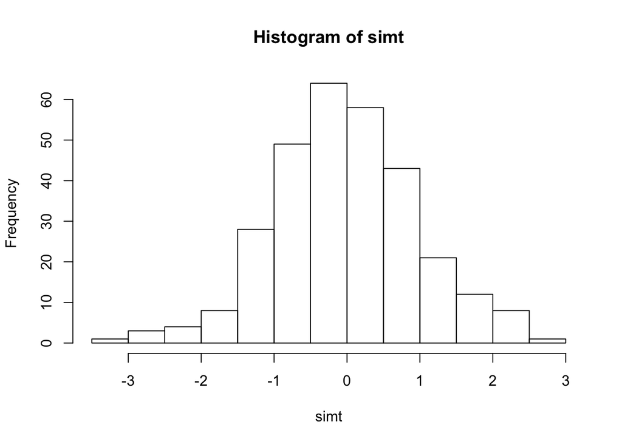

```r
hist(simt) #examine histogram
```

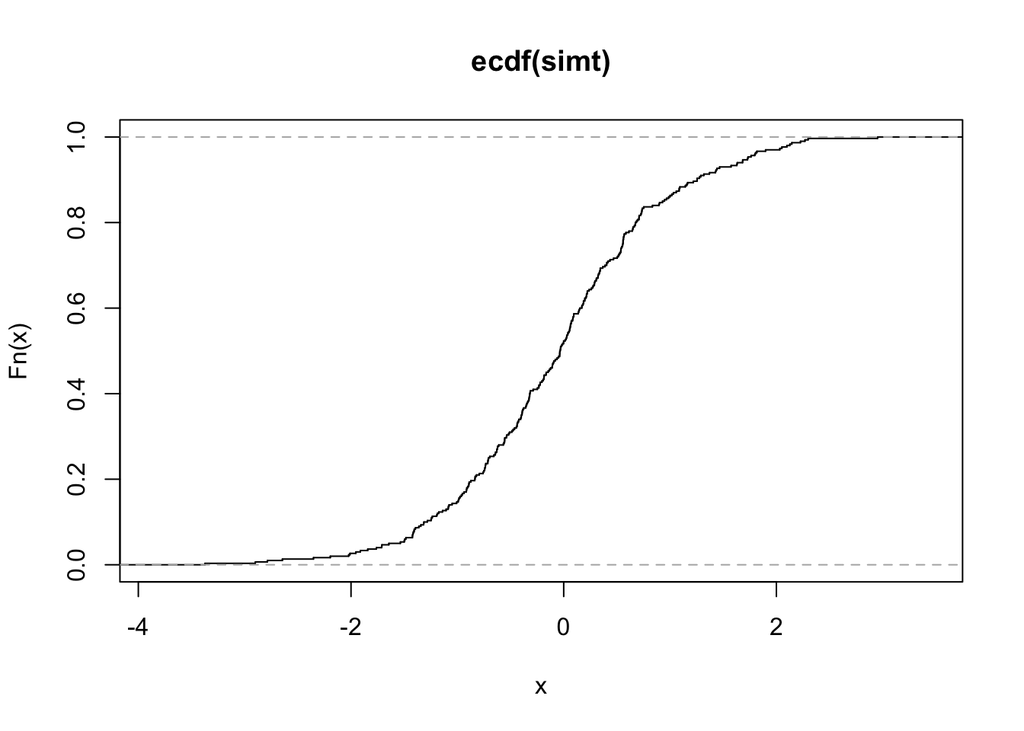

```r
plot(ecdf(simt), do.points=FALSE, verticals=TRUE) #plot the distribution function
```

```r
shapiro.test(simt) #Shapiro-Wilk test
```

```
##
##  Shapiro-Wilk normality test
##
## data:  simt
## W = 0.99399, p-value = 0.281
```

```r
ks.test(simt, "pnorm", mean = mean(simt), sd = sqrt(var(simt))) #One-sample Kolmogorov-Smirnov test
```

```
##
##  One-sample Kolmogorov-Smirnov test
##
## data:  simt
## D = 0.046547, p-value = 0.534
## alternative hypothesis: two-sided
```

### Chapter 9

1. What is the difference between `if() else` and `ifelse()`?

```r
#ifelse(test, what to return if test is true, what to return if test is false) is a vectorized version of the if/else concept that applies the test to each item of a vector and returns the true or false value for each item
ex1 <- c(1:12)
ifelse(ex1>=7,"upper","lower")
```

```
##  [1] "lower" "lower" "lower" "lower" "lower" "lower" "upper" "upper"
##  [9] "upper" "upper" "upper" "upper"
```

```r
#if() else evaluates a condition once, unless part of a for loop

if (6<7) "RIGHT!" else "NO WAY!"
```

```
## [1] "RIGHT!"
```

2. Demonstrate the use of a `for()` loop.

```r
#To get the square of each of the integers 1-5
odd = c(1:5)
odd_sq = NULL

for (i in 1:5) {
odd_sq [i] = odd [i]^2
}
print(odd_sq)
```

```
## [1]  1  4  9 16 25
```